# **[Universidade Federal Rural de Pernambuco](http://ufrpe.br/)** **[Departamento de Matemática](http://www.dm.ufrpe.br/)** **[Disciplina: Cálculo M I](https://sites.google.com/site/ricardonunesmachadojr/disciplinas/c%C3%A1lculo-mi)** **[Prof. Ricardo Machado](https://sites.google.com/site/ricardonunesmachadojr/)**

## [Índice de Aulas](https://sagectu.com.br/calculo1.github.io/index.html) Aula 5

## Derivada de função implícita Aproximações Lineares Diferencial

# Referências:

[figure not shown]

[figure not shown]

### Observação: Nota de aula produzida usando o software [SageMath](http://www.sagemath.org/), usando o notbook [Jupyter](https://jupyter.org/). Use o SageMathCell com vários exemplos em: sagectu.com.br/sagecell.html

## 1 - Derivada de função implícita

## Uma função está escrita na *forma explícita* quando a variável $y=f(x)$ está de uma lado da igualdade e do outro lado os termos em $x$. Caso contrário, a função está escrita na *forma implícita*.

## Exemplo 1 Função na forma explícita. $f:\mathbb{R}\setminus\{-2\} \rightarrow \mathbb{R}$, com $y = f(x)$, dada por: $$ y = \frac{3+x}{x+2} $$ Forma implícita da função: $$ xy+2y-x=3 $$

## Exemplo 2 Derivando a função do Exemplo 1, dada na forma explícita. $$ y' = \frac{1\cdot (x+2)-(3+x)\cdot 1}{(x+2)^2} = \frac{-1}{(x+2)^2}$$

[figure not shown]

## Exemplo 3 Derivando a função do Exemplo 1, dada na forma implícita. a função $y$ deve ser vista como função de $x$, ou seja, como $y(x)$, assim: $$ x\cdot y(x)+2\cdot y(x)-x=3 $$ E aplicamos as regras da soma e do produto: $$ x\cdot y(x)+2\cdot y(x)-x=3 \Rightarrow $$ $$ (x\cdot y(x)+2\cdot y(x)-x)'=(3)'\Rightarrow $$ $$ (x\cdot y(x))'+(2\cdot y(x))'+(-x)')=0 \Rightarrow $$ $$ \overbrace{1\cdot y(x) + x\cdot y'(x)}^{\text{regra do produto}} +2\cdot y'(x) - 1 = 0 \Rightarrow $$ $$ x\cdot y'(x) +2\cdot y'(x) = 1-y(x) \Rightarrow $$ $$ y'(x)\cdot(x+2) = 1-y(x) \Rightarrow $$ $$ y' = \frac{1-y}{x+2} ~~~ (*) $$ Como $y = \dfrac{3+x}{x+2}$, substituindo em $(*)$, temos: $$ y' = \frac{1-y}{x+2} = \frac{1-\frac{3+x}{x+2}}{x+2} = \frac{(x+2)-(3+x)}{(x+2)^2} = \frac{-1}{(x+2)^2}$$

[figure not shown]

[figure not shown]

```python
y = var('y')
f = x*y + 2*y - x -3
show(f.implicit_derivative(y,x))
```

$$\newcommand{\Bold}[1]{\mathbf{#1}}-\frac{y - 1}{x + 2}$$

## Observação: Observe os Exemplos 2 e 3, trabalho exigido para calcular a mesma derivada foi bem maior no caso da derivada implícita. Qual a vantagem em aprender esse método?

## Exercício 1 Expresse $\frac{dy}{dx}$ em termos de $x$ e de $y$, na qual $y=f(x)$ é uma função diferenciável dada implicitamente pela equação a) $xy^2+2y=3$ b) $y^5+y=x$ c) $xe^y+xy=3$

```python
y = var('y')
f = x*y^2 + 2*y - 3
show(f.implicit_derivative(y,x))
```

$$\newcommand{\Bold}[1]{\mathbf{#1}}-\frac{y^{2}}{2 \, {\left(x y + 1\right)}}$$

```python
y = var('y')
f = y^5 + y - x
show(f.implicit_derivative(y,x))
```

$$\newcommand{\Bold}[1]{\mathbf{#1}}\frac{1}{5 \, y^{4} + 1}$$

```python
y = var('y')
f = x*e^y + x*y - 3
show(f.implicit_derivative(y,x))
```

$$\newcommand{\Bold}[1]{\mathbf{#1}}-\frac{y + e^{y}}{x e^{y} + x}$$

## Exercício 2 Suponha que $y=f(x)$ seja uma função derivável dada implicitamente pela equação $y^3+2xy^2+x=4$. Suponha, ainda que, $1\in D_f$. a) Calcule $f(1)$ b) Determine a equação da reta tangente ao gráfico de $f$ no ponto de abscissa $1$.

## 2 - Aproximações Lineares

## Considere uma curva derivável $f(x)$ e um ponto $(p, f(p))$ sobre ela. Em seguida, considere a reta tangente ao gráfico de $f$ no ponto $(p, f(p))$, que possui equação $L(x) = f(p) + (p)(x − p)$.

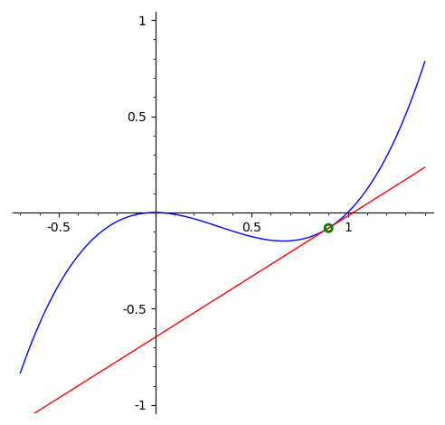

```python
grafico_f_tan(x^3 - x^2, 0.9, (-0.7, 1.4), (-1, 1))
```

## Olhando de perto, a região próxima do ponto $(p, f (p))$, notamos que a curva se aproxima bastante da reta tangente, como podemos observar abaixo:

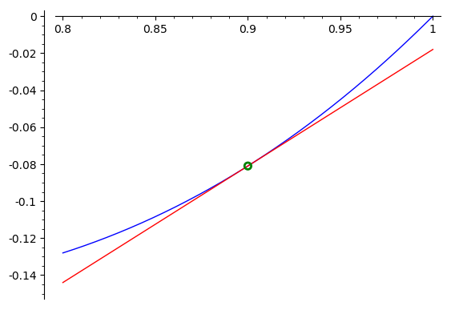

```python
grafico_f_tan(x^3 - x^2, 0.9, (0.8, 1), (-0.15, 0))
```

## Aproximação Linear: Dizemos então que a reta tangente é uma boa aproximação para o gráfico de $f$ (de fato, num certo sentido, dizemos que a função $L$ é a função polinomial de primeiro grau que melhor aproxima, localmente, a função $f$). Denotamos esta aproximação por $f(x) ≈ L(x)$, para x suficientemente próximo de $p$ . Assim, $$ f(x) ≈ f(p) + f'(p)(x − p) $$ Essa aproximação é chamada de *aproximação linear de* $f$ *em torno de* $p$.

## Linearização: A função dada por $$ L(x) = f(p) + f'(p)(x − p) $$ é chamada de *linearização* de $f$ em $p$.

## Exemplo 4 Considere $f (x) = \text{sen} (x)$. Determine a linearização de $f$ em $p = 0$. Utilize essa linearização para determinar uma aproximação de $\text{sen}(0,1)$ . Utilize uma calculadora para determinar o erro cometido.

## Solução (Exemplo 4) Note que $f'(x) = \cos x$ e que $f(0) = 0$ e $f'(0) = 1$. Sendo assim, a linearização desejada é $$ L(x) = f(0) + f'(0)(x − 0) = 0 + 1\cdot(x − 0) = x. $$ Assim, para determinar uma aproximação para $sen(0,1)$, basta lembrar que $$ L(x) ≈ f (x).$$ Sendo assim, como $L(0,1) = 0,1$, temos $$ \text{sen}(0,1) ≈ 0,1 $$ Utilizando uma calculadora, obtemos que

```python
abs(sin(0.1)-0.1)
```

```
0.000166583353171851
```

## Desse modo, o erro obtido na aproximação é de $0,016\%$.

## Exercício 3 Encontre a linearização de $f (x) = 5x − 2$ em $p = 2$.

```python
y = var('y')
f = 5*x-2
(y - f(2) == diff(f, x)(x=2)*(x-(2))).show()
(y == diff(f, x)(x=2)*(x-(2)) + f(2)).show()
```

$$\newcommand{\Bold}[1]{\mathbf{#1}}y - 8 = 5 \, x - 10$$

$$\newcommand{\Bold}[1]{\mathbf{#1}}y = 5 \, x - 2$$

## Exercício 4 Encontre a aproximação linear da função $g(x) = \sqrt[3]{1+x}$ em torno de $x=0$ e use-a para aproximar os números $\sqrt[3]{0,95}$ e $\sqrt[3]{1,1}$.

```python
y = var('y')
f = (1+x)^(1/3)
(y - f(0) == diff(f, x)(x=0)*(x-(0))).show()
h = diff(f, x)(x=0)*(x-(0)) + f(0)
(y == diff(f, x)(x=0)*(x-(0)) + f(0)).show()
```

$$\newcommand{\Bold}[1]{\mathbf{#1}}y - 1 = \frac{1}{3} \, x$$

$$\newcommand{\Bold}[1]{\mathbf{#1}}y = \frac{1}{3} \, x + 1$$

```python
h(x=-0.05)
```

```
0.983333333333333
```

```python
h(x=0.1)
```

```
1.03333333333333
```

## 3 - Diferencial

## Até aqui, $\frac{dy}{dx}$ tem sido visto como uma simples notação para a derivada de $y=f(x)$. Agora, vamos interpretar $\frac{dy}{dx}$ como um *quociente* entre dois acréscimos. Tomemos um ponto $(x, f (x))$ sobre o gráfico e denotemos por $∆x$ um acréscimo em $x$, como mostrado abaixo:

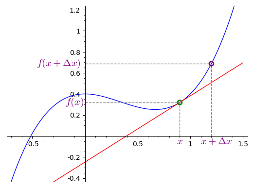

```python
diferencial(x^3 - x^2+0.4)
```

## Chamando $dy$ a variação sofrida pela linearização $L$ de $f$ em $p$ (cujo gráfico é a reta tangente ao gráfico de $f$ em $p$), correspondente ao acréscimo $dx = ∆x$ , a partir do ponto $p$ , como ilustrado abaixo

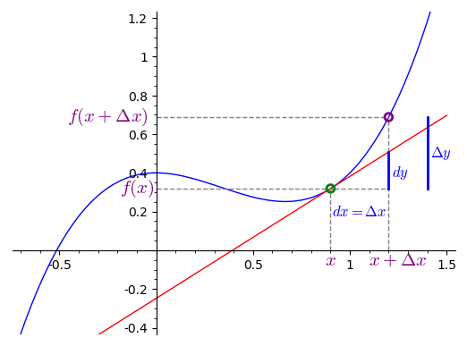

```python
diferencial2(x^3 - x^2+0.4)
```

## Como a derivada é o coeficiente angular da reta tangente, temos $$f'(x) = \tan{\alpha} = \frac{dy}{\Delta x}$$ e portanto $$ dy = f'(x)\Delta x. $$ Observe que $$ \Delta y = f(x+\Delta x)-f(x) $$ Tomando $∆x$ cada vez mais próximo de zero e que este limite é a derivada, teremos que $$ \lim_{\Delta x \rightarrow 0} \frac{\Delta y}{\Delta x} = f'(x) $$

## Logo, para $∆x$ muito próximo de zero, podemos considerar $$ \frac{\Delta y}{\Delta x} ≈ f'(x) \text{ ou ainda } \Delta y ≈ f'(x)\Delta x $$ Dessa forma, para $∆x = dx$ , obtemos a seguinte aproximação: $$ ∆y ≈ dy = f'(x)dx $$

## Exercício 5 Compare os valores de $∆y$ e $dy$ se $y = x^3 + x^2 − 2x + 1$ e $x$ varia de $2$ para $2,05$.

```python
f = x^3+x^2-2*x+1
f(2.05) - f(2) #Delta y
```

```
0.717624999999998
```

```python
diff(f, x)(x=2.05)*0.05 #dy
```

```
0.735375000000000
```

## Exercício 6 Utilizando a diferencial, calcule um valor aproximado para o acréscimo $\Delta y$ que a função $y=x^2$ sofre quando se passa de $x=1$ a $a+dx=1,001$. Calcule o erro.

```python
f = x^2
diff(f, x)(x=1.001)*0.001 # dy
```

```
0.00200200000000000
```

```python
f(x=1.001)-f(x=1) #Delta y
```

```
0.00200099999999970
```

```python
f(x=1.001)-f(x=1) - diff(f, x)(x=1.001)*0.001 #erro
```

```
-1.00000000030241e-6
```